# Model assessment for georeferenced data in 2D

Day 2, Afternoon

Instructor: Sara Martino

Start by loading useful libraries:

```r
library(ggplot2)
library(INLA)
library(inlabru)
#library(mgcv)
library(viridis)
```

# 1 Data Simulation

We will now construct a 2D model with non-Gaussian observation noise, estimate three alternative models, and look at some model assessment tools. The model is as follows:
$$y(s)\sim\text{T}_{\nu}(\eta(s), \tau);\ s\in\mathcal{D}$$
Where $\text{T}_{\nu}(\cdot,\cdot)$ is a Student-t distribution with $\nu$ degrees of freedom, mean $\eta(s)$ and reparametrised so that the precision is $\tau$ for all the values of $\nu$.

Morevoer we have taht
$$\eta(s) = \mu + u(s)$$
where

- $\mu$ is a constant mean
- $u(s)$ is a Matern field over a 10$$10 squared domain.

First, we build a high resolution mesh for the true field, using low level INLA functions

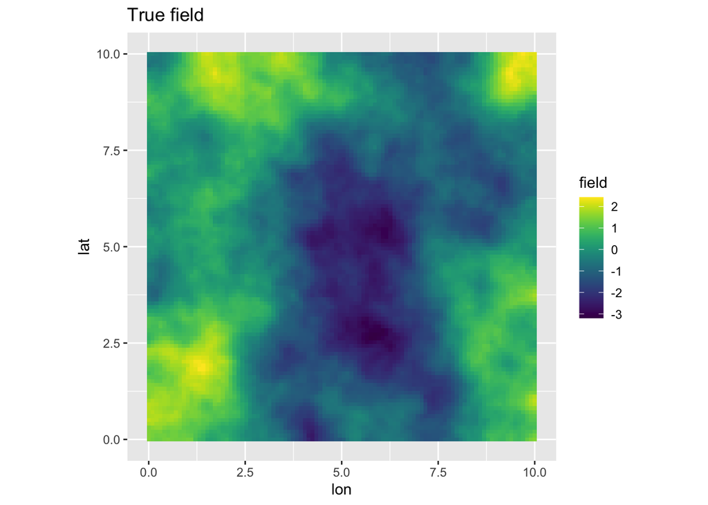

```r
bnd <- spoly(data.frame(lon = c(0, 10, 10, 0), lat = c(0, 0, 10, 10)),
             crs=inla.CRS("longlat"))
mesh_fine <- inla.mesh.2d(boundary = bnd, max.edge = 0.2)

# Note: the priors here will not be used in estimation

matern_fine <-
  inla.spde2.pcmatern(mesh_fine,
                      prior.sigma = c(1, 0.01),
                      prior.range = c(1, 0.01))
# choose range and sd for the matern field
true_range <- 4
true_sigma <- 1

# Extract the Q matrix
true_Q <- inla.spde.precision(matern_fine, theta=log(c(true_range, true_sigma)))

# simulate from the matern field
true_field <- inla.qsample(1, true_Q, seed = 1234L)[,1]

truth <- expand.grid(lon=seq(0, 10, length=100),
                     lat=seq(0, 10, length=100))
truth$field <- inla.mesh.project(mesh_fine,
                                 loc = as.matrix(truth),
                                 field = true_field)
coordinates(truth) <- c("lon", "lat")
truth <- as(truth, "SpatialPixelsDataFrame")

ggplot() +
  gg(truth, mapping=aes_string("lon","lat",fill="field")) +
   coord_equal() +
              ggtitle("True field")+
  scale_fill_viridis()
```

Extract observations from some random locations, and add Student-T distributed observation noise:

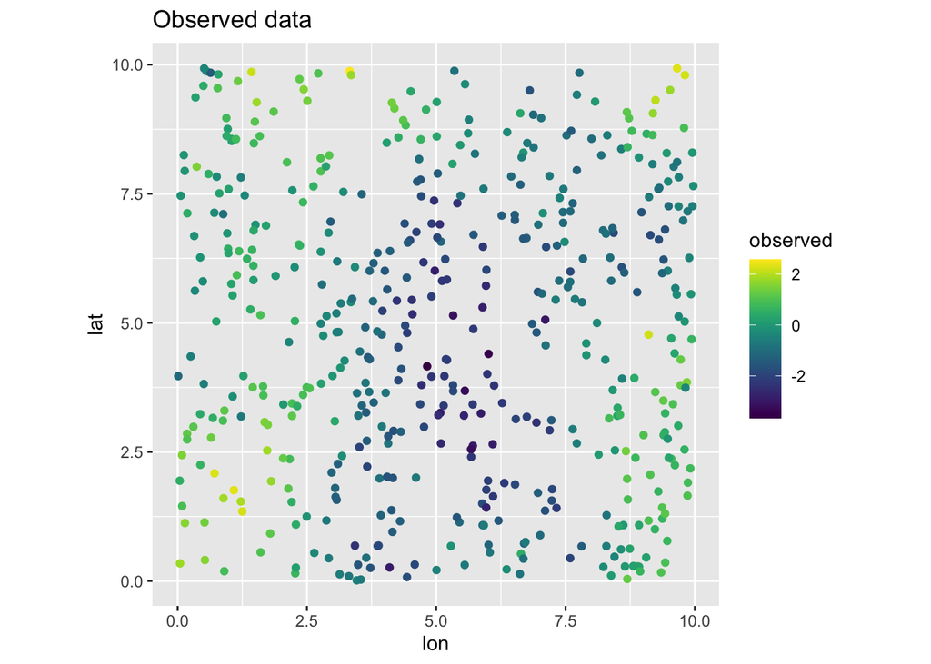

```r
n <- 500
nu = 3
mydata <- data.frame(lon = runif(n, 0, 10), lat = runif(n, 0, 10))
mydata$observed <- inla.mesh.project(mesh_fine,
                                     loc = as.matrix(mydata),
                                     field = true_field) +
                   rt(n, df = nu)/sqrt(nu*(nu-2)) * 0.4
coordinates(mydata) <- c("lon", "lat")

ggplot() + gg(mydata, aes(color = observed)) +
  coord_equal() +
  scale_color_viridis() + ggtitle("Observed data")
```

# 2 Fit the models

Construct a mesh covering the data:

[figure not shown]

```r
mesh <- inla.mesh.2d(boundary = bnd,
                     cutoff = 2,
                     offset = c(1,2),
                     max.edge = c(0.7,1,5))
plot(mesh)
```

Construct an SPDE model object for a Matern model:

```r
matern <-
  inla.spde2.pcmatern(mesh,
                      prior.sigma = c(10, 0.01),
                      prior.range = c(1, 0.01))
```

Specify the model components:

```r
cmp <- observed ~ field(coordinates,
                        model = matern) +
                  Intercept(1)
```

We fit 3 different models to the dataset, with assessment scores activated.

- The fist model has a Gaussian likelihood and only a common intercept
- The second model has a Gassian likelihood and a linear predictor consisting of a common mean and a Matern field.
- The thord model has a Student-t likelihood and a linear predictor consisting of a common mean and a Matern field.

```r
c.c <- list(cpo = TRUE,
            dic = TRUE,
            waic = TRUE,
            config = TRUE)

fit.zero <- bru( observed ~ Intercept(1),
                data = mydata,
                family="gaussian",
                options = list(control.compute = c.c))

fit.norm <- bru( cmp,
                data = mydata,
                family="gaussian",
                options = list(control.compute = c.c))

fit.T <- bru(cmp,
             data = mydata,
             family="T",
             options = list(control.compute = c.c))
```

**Exercise 1:** Check the output of the three models. You can also compare the predictions at the observation points form the three models.

# 3 Model check

## 3.1 PIT values

PIT are uniformly distributed under the true model. The usual plotting method for PIT is a histogram.

- For models with too small predictive variance, the histogram tends to increase toward 0 and 1.
- For models with too large predictive variance, the histogram tends to have peak in the middle.
- For incorrectly skewed predictions, the histogram will tend to be skewed.

Unfortunately, that doesn’t necessarily imply that overfitting and oversmoothing can be detected.

For the three estimated models we have :

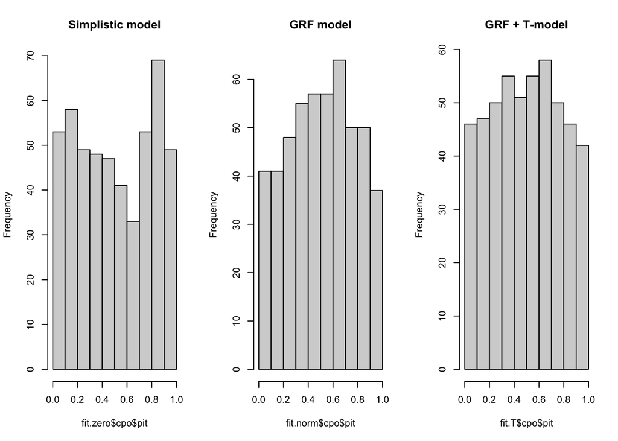

```r
par(mfrow=c(1,3))
hist(fit.zero$cpo$pit, main="Simplistic model")
hist(fit.norm$cpo$pit, main="GRF model")
hist(fit.T$cpo$pit, main="GRF + T-model")
```

```r
par(mfrow=c(1,1))
```

The empirical cumulative distribution functions may be easier to analyse (a perfect model has the empirical CDF along the straight line):

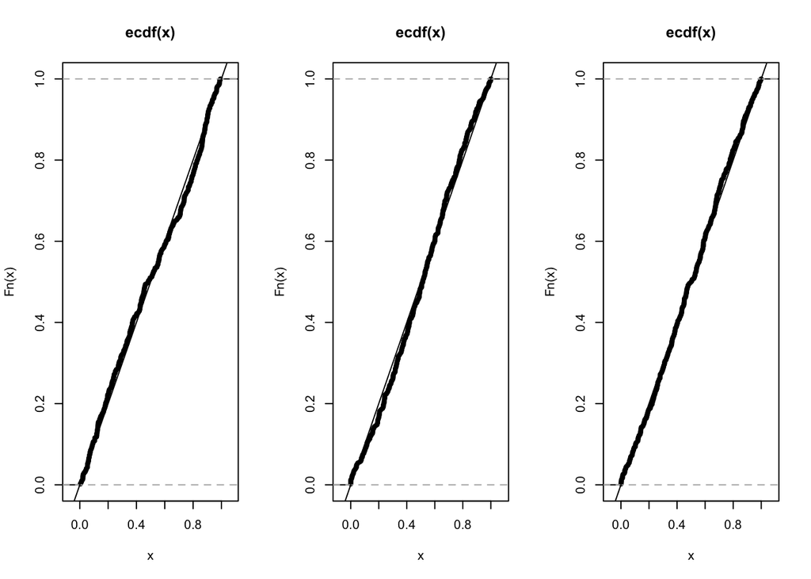

```r
par(mfrow=c(1,3))
plot.ecdf(fit.zero$cpo$pit); abline(0, 1)
plot.ecdf(fit.norm$cpo$pit); abline(0, 1)
plot.ecdf(fit.T$cpo$pit); abline(0, 1)
```

```r
par(mfrow=c(1,1))
```

According to these plots, it’s not clear if the model that matches the truth, the GRF + T-distribution model, isn’t actually any better than the fully Gaussian model; even the simplistic model looks good. It sees the Gaussian-ness of the random field, and misses the non-Gaussian observation noise!

Formal Kolmogorov-Smirnov test for uniformity reiterates this, based on the difference in CDF between PIT and a uniform distribution.

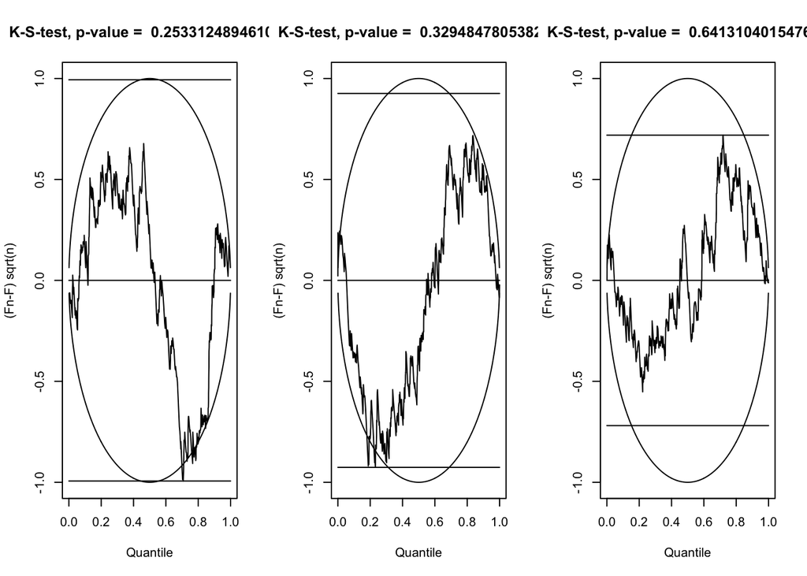

```r
par(mfrow=c(1,3))
inla.ks.plot(x=fit.zero$cpo$pit, punif)
inla.ks.plot(x=fit.norm$cpo$pit, punif)
inla.ks.plot(x=fit.T$cpo$pit, punif)
```

```r
par(mfrow=c(1,1))
```

## 3.2 CPO values

Let’s look at CPO instead; it can be summarised into a log-CPO-score, which can be compared qualitatively with DIC and WAIC after multiplying with a factor 2:

```r
scores <- data.frame(
  cpo=c(zero = -sum(log(fit.zero$cpo$cpo)),
        norm = -sum(log(fit.norm$cpo$cpo)),
        T    = -sum(log(fit.T$cpo$cpo))),
  "cpo.2"=2*c(zero = -sum(log(fit.zero$cpo$cpo)),
              norm = -sum(log(fit.norm$cpo$cpo)),
              T    = -sum(log(fit.T$cpo$cpo))),
  dic=c(zero = fit.zero$waic$waic,
        norm = fit.norm$waic$waic,
        T    = fit.T$waic$waic),
  waic=c(zero = fit.zero$dic$dic,
         norm = fit.norm$dic$dic,
         T    = fit.T$dic$dic))
rownames(scores) <- c("simple_normal", "field_normal", "field_T")
scores
```

```
##                    cpo     cpo.2       dic      waic
## simple_normal 811.9753 1623.9505 1623.9507 1624.2536
## field_normal  340.0822  680.1644  664.7212  655.8765
## field_T       290.5912  581.1824  576.8933  569.6220
```

We see that for the simplistic model that did not include any random field, all three scores are extremely close to each other.

For the two random field models, the log-CPO-score appears to make a clearer distinction between the incorrect (Gaussian) and correct (Student-T) observation likelihood than DIC and WAIC does.

Instead of comparing aggregated scores for different models, we can look at the distribution of individual log-CPO scores:

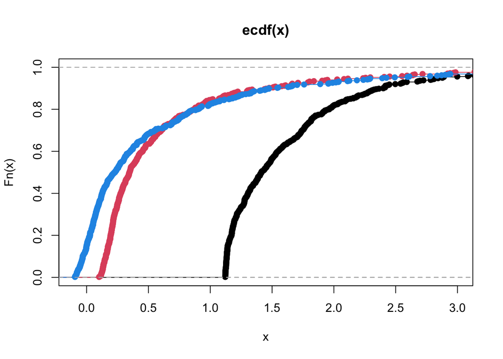

```r
xlimit <- c(-0.1, 3)
plot.ecdf(-log(fit.zero$cpo$cpo), xlim=xlimit, col=1)
plot.ecdf(-log(fit.norm$cpo$cpo), xlim=xlimit, col=2, add=TRUE)
plot.ecdf(-log(fit.T$cpo$cpo), xlim=xlimit, col=4, add=TRUE)
```

The scores for the simplistic model (in black) are consistently large. The score distribution for the Gaussian likelihood model (in red) is shifted towards worse predictions (larger scores) than for the Student-T model.

For model comparison, a potentially more useful approach is to consider the pairwise score differences for each observation:

```r
cpo.zero.norm <- -log(fit.zero$cpo$cpo) + log(fit.norm$cpo$cpo)
cpo.zero.T <- -log(fit.zero$cpo$cpo) + log(fit.T$cpo$cpo)
cpo.norm.T <- -log(fit.norm$cpo$cpo) + log(fit.T$cpo$cpo)
```

The empirical CDFs of the score differences can reveal if a model is consistently better or worse across all observation locations. Taking differences in the order of the aggregated model scores gives the following:

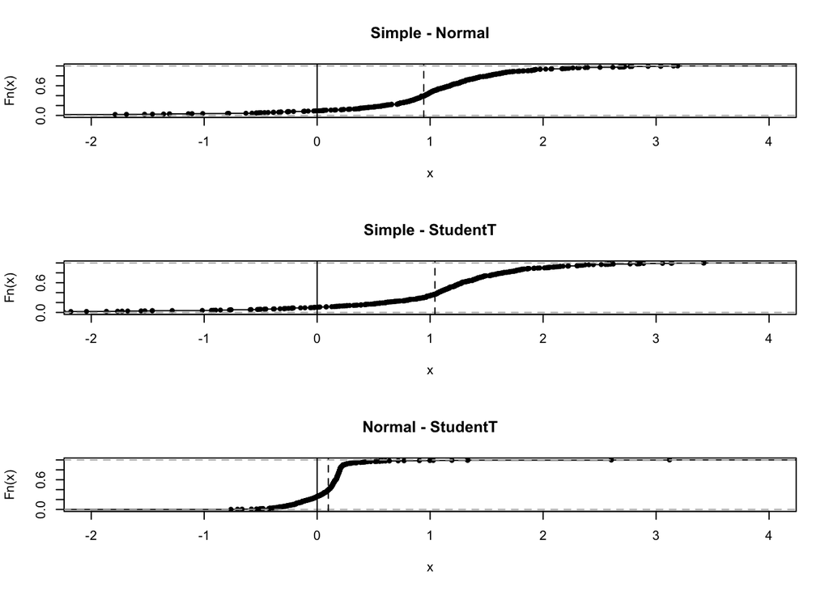

```r
par(mfrow=c(3,1))
plot.ecdf(cpo.zero.norm, xlim=c(-2, 4), main="Simple - Normal")
abline(v = 0)
abline(v = mean(cpo.zero.norm), lty=2)
plot.ecdf(cpo.zero.T, xlim=c(-2, 4), main="Simple - StudentT")
abline(v = 0)
abline(v = mean(cpo.zero.T), lty=2)
plot.ecdf(cpo.norm.T, xlim=c(-2, 4), main="Normal - StudentT")
abline(v = 0)
abline(v = mean(cpo.norm.T), lty=2)
```

```r
par(mfrow=c(1,1))
```

We see that the Simple model is consistently worse than the other models. The difference between the Normal and Student T likelihood models is less consistent.

Is there a pattern to which observations get improved predictions under the true model? Let do scatter plots of scores and score differences:

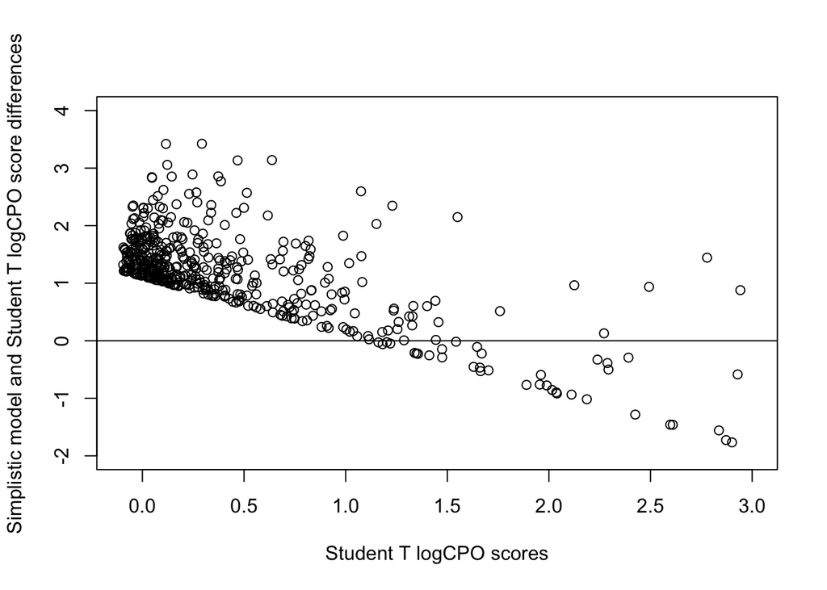

```r
plot(-log(fit.T$cpo$cpo), cpo.zero.T,
     xlim=xlimit, ylim=c(-2, 4),
     xlab="Student T logCPO scores",
     ylab="Simplistic model and Student T logCPO score differences")
abline(h = 0)
```

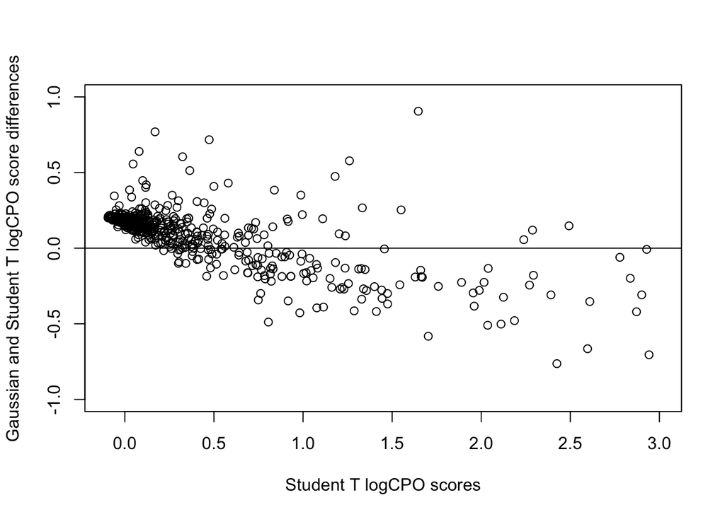

```r
plot(-log(fit.T$cpo$cpo), cpo.norm.T,
     xlim=xlimit, ylim=c(-1, 1),
     xlab="Student T logCPO scores",
     ylab="Gaussian and Student T logCPO score differences")
abline(h = 0)
```

The scatter plots are not so easy to interpret. There is a tendency for observations that are well predicted by the true, Student-T model (small scores) to have worse scores (positive differences in the plots) for the simpler models (the Simplistic and Normal likelihood models), and observations that are hard to predict under the true model (large scores) to have better scores (negative differences) in the simpler models.